# ELE618 - Sistemas Elétricos Industriais

Instalações Elétricas - Ademaro A. M. B. Cotrim  
Cap3 - Ademaro A. M. B. Cotrim

Prof. Dr. Thales A. C. Maia

UFMG - DEE

# 3.1 A corrente elétrica no corpo humano

## Os Perigos da Eletricidade

- A corrente elétrica que passa pelo corpo humano pode causar danos sérios.
- Efeitos dependem da intensidade, duração e do trajeto da corrente.
- Principais fenômenos: tetanização, parada respiratória, queimadura e fibrilação ventricular.

## Limite de largar e Tetanização

- **Limite de largar**: Máxima corrente que uma pessoa suporta e ainda consegue soltar o condutor.
- Média de 10 mA (mulheres) a 16 mA (homens) em 50/60 Hz.
- **Tetanização**: Contração muscular contínua induzida pela corrente, impedindo que a pessoa solte a parte energizada.
- Frequências de 50 a 60 Hz são muito favoráveis a esse fenômeno (piores para segurança).

## Queimaduras e Fibrilação Ventricular

- **Queimaduras**: Devidas ao efeito Joule; podem ser severas nos pontos de entrada e saída.
- **Fibrilação ventricular**: Fenômeno mais perigoso; contrações desordenadas do coração.
- Interrompe a circulação do sangue, provocando queda da pressão e morte se não houver socorro imediato.
- A probabilidade aumenta em certas partes (período vulnerável) do ciclo cardíaco.

## Fibrilação Ventricular e Pressão Arterial

O fenômeno fisiológico mais grave que pode ocorrer quando a corrente elétrica passa pelo corpo humano é a fibrilação ventricular do coração. Trata-se de um fenômeno complexo e geralmente fatal.

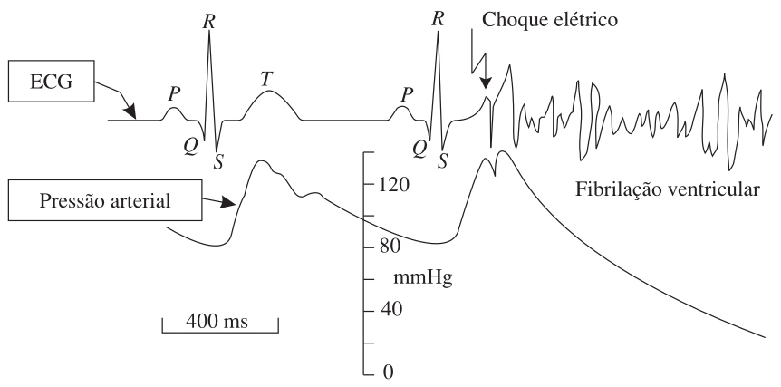

Fig. 1: Eletrocardiograma (ECG) que mostra a fibrilação ventricular e a pressão arterial (Cotrim, 2009)

## Zonas de Efeito da Corrente e Frequência

- As reações no corpo são divididas em zonas de efeitos conforme a intensidade da corrente e o tempo de duração.
- O efeito da corrente diminui com o aumento da frequência (acima de 100 Hz, o risco de fibrilação se altera e ocorre o efeito skin).
- O trajeto da corrente (ex: mão-mão vs. mão-pé) define a gravidade. Fator de corrente do coração ajuda nessa análise.

## Zonas de Efeito (50 ou 60 Hz)

No caso de corrente alternada com frequência de 15 a 100 Hz, são caracterizadas zonas de efeitos fisiológicos que vão desde nenhuma reação (Zona 1) até risco severo de fibrilação (Zona 5).

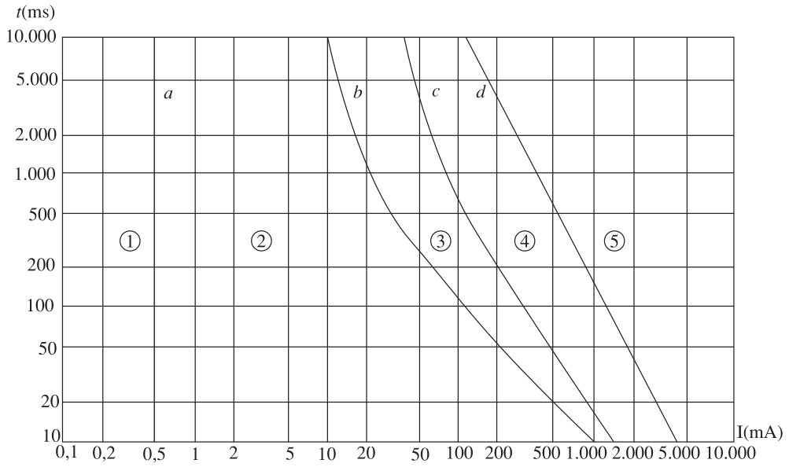

Fig. 2: Zonas de efeito de corrente alternada (50 ou 60 Hz) sobre adultos (Cotrim, 2009)

## Impedância do Corpo Humano

- O corpo é comparável a resistores e capacitores; com variações de pessoa para pessoa.
- Depende do trajeto (ex: mão/pé é 1000 a 1500 ohms).
- Pode diminuir com tensão, umidade da pele, aumento da área e pressão de contato.

# 3.2 Fundamentos da Proteção

## Critérios de Proteção

- Baseia-se no limite admissível da tensão de contato.
- Depende das condições de influência externa (seco, úmido, submerso).
- Situações classificam-se como situação 1, 2 ou 3 conforme o contato do corpo (ex: resistência varia).
- A finalidade é evitar que choques alcancem as zonas perigosas (fibrilação).

# 3.3 Aterramento e Equipotencialização

## Aterramento

- É a ligação intencional à terra, visando um caminho seguro para a corrente de falta.
- Aterramento do sistema (funcional): Ponto neutro aterrado para controle de tensões.
- Aterramento de proteção: Conexão das massas (carcaças) à terra.

## Variação das Tensões no Solo

A tensão gerada pela corrente se distribui no solo ao redor da haste de aterramento. Ela atinge o valor máximo na haste e diminui conforme a distância aumenta, aproximando-se de zero em um ponto suficientemente distante.

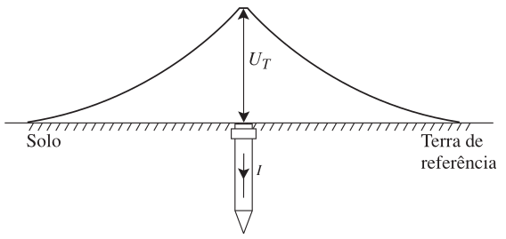

Fig. 3: Variação das tensões geradas no solo pela passagem de corrente em um eletrodo de aterramento (Cotrim, 2009)

## Condutor Equivalente de Aterramento

Para entender a resistência de aterramento, a dispersão de corrente por um eletrodo no solo pode ser vista como um condutor de seção variável, cuja área cresce com a distância, diminuindo a resistência local.

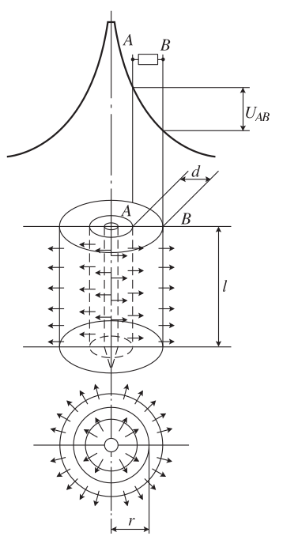

Fig. 4: Condutor elétrico equivalente de seção variável (Cotrim, 2009)

## Equipotencialização

- Interligação de elementos condutores para minimizar as diferenças de potencial entre eles.
- Pode ser principal (BEP) ou suplementar (locais específicos, como banheiros).
- Ajuda a garantir que pessoas em contato com diferentes massas simultaneamente não sofram choque.

## Barramento de Eqüipotencialização Principal (BEP)

O BEP centraliza as conexões do condutor de aterramento, condutores de proteção, neutro e massas metálicas da edificação, garantindo a equalização de potencial.

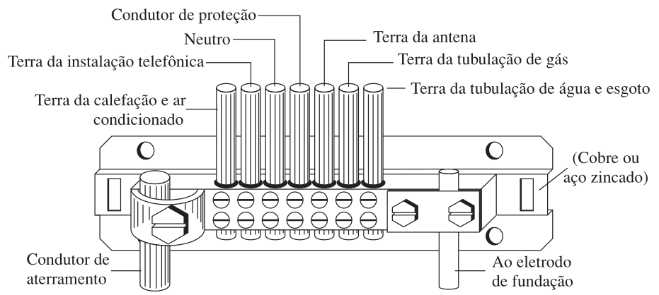

Fig. 5: Barramento de eqüipotencialização principal (Cotrim, 2009)

## Esquemas de Aterramento (TN, TT, IT)

- Define a relação da alimentação e as massas com a terra.
- Primeira letra (T ou I): Situação da alimentação em relação à terra (Aterrada ou Isolada).
- Segunda letra (N ou T): Situação das massas em relação à terra (Ligadas ao Neutro ou Terra direta).

# 3.4 Isolações e Graus de Proteção

## Isolações

- Isolação básica: aplicada a partes vivas para proteção básica.
- Isolação suplementar: aplicada em adição à básica.
- Isolação dupla: compreende ambas.
- Isolação reforçada: sistema de isolação única que provê o mesmo nível de proteção.

## Classes dos Equipamentos e Graus de Proteção

- Classes I, II, III dependem das medidas de isolação.
- Grau de proteção (IP): Dois algarismos indicam resistência contra ingresso de corpos sólidos/pó (1º) e água (2º).
- Códigos IP (ex: IP54) auxiliam na escolha apropriada do material para cada ambiente.

# 3.5 Proteção Básica

## Métodos de Proteção Básica

- Visa evitar o contato com partes energizadas.
- Isolação de partes vivas (revestimentos dielétricos).
- Barreiras e invólucros (evitar acesso com dedos e ferramentas).
- Uso de obstáculos e distanciamento.

# Exercícios

## Exercícios

1. Quais são os principais efeitos que uma corrente elétrica externa pode produzir no corpo humano? . . .
2. Defina o que é o conceito “limite de largar” de uma corrente elétrica. . . .
3. Quais são os valores médios do “limite de largar” em corrente alternada para 50 e 60 Hz para homens e mulheres? . . .
4. O que é o fenômeno da fibrilação ventricular? . . .
5. Quais são as principais variáveis que influem no valor da resistência elétrica do corpo humano? . . .

## Exercícios (cont.)

6. Como se definem proteção básica e proteção supletiva? . . .
7. O que são proteção passiva e proteção ativa contra choques elétricos? . . .
8. Quais as condições de influências externas devem ser observadas na seleção das medidas de proteção contra choques elétricos (por contato direto ou indireto)? . . .
9. Qual é a diferença entre aterramento e eqüipotencialização? . . .
10. Que valores podem ter as duas letras utilizadas na simbologia dos esquemas básicos de aterramento, para representar a função do aterramento da fonte de alimentação da instalação (transformador, no caso mais comum, ou gerador) e das massas? . . .

# Obrigado!

http://thalesmaia.com/